# exercise 3

*Describe the work you have done this week and summarize your learning.*

- Describe your work and results clearly.
- Assume the reader has an introductory course level understanding of writing and reading R code as well as statistical methods.
- Assume the reader has no previous knowledge of your data or the more advanced methods you are using.

```r
date()
```

```
## [1] "Sat Nov 14 13:39:35 2020"
```

*2.Read the joined student alcohol consumption data into R either from your local folder* Here is some code

```r
# access the dplyr library
library(dplyr)
alc<-read.csv(file = "data/alc.csv")
glimpse(alc)
```

```
## Rows: 382
## Columns: 35
## $ school     <chr> "GP", "GP", "GP", "GP", "GP", "GP", "GP", "GP", "GP", "G...
## $ sex        <chr> "F", "F", "F", "F", "F", "M", "M", "F", "M", "M", "F", "...
## $ age        <int> 18, 17, 15, 15, 16, 16, 16, 17, 15, 15, 15, 15, 15, 15, ...
## $ address    <chr> "U", "U", "U", "U", "U", "U", "U", "U", "U", "U", "U", "...
## $ famsize    <chr> "GT3", "GT3", "LE3", "GT3", "GT3", "LE3", "LE3", "GT3", ...
## $ Pstatus    <chr> "A", "T", "T", "T", "T", "T", "T", "A", "A", "T", "T", "...
## $ Medu       <int> 4, 1, 1, 4, 3, 4, 2, 4, 3, 3, 4, 2, 4, 4, 2, 4, 4, 3, 3,...
## $ Fedu       <int> 4, 1, 1, 2, 3, 3, 2, 4, 2, 4, 4, 1, 4, 3, 2, 4, 4, 3, 2,...
## $ Mjob       <chr> "at_home", "at_home", "at_home", "health", "other", "ser...
## $ Fjob       <chr> "teacher", "other", "other", "services", "other", "other...
## $ reason     <chr> "course", "course", "other", "home", "home", "reputation...
## $ nursery    <chr> "yes", "no", "yes", "yes", "yes", "yes", "yes", "yes", "...
## $ internet   <chr> "no", "yes", "yes", "yes", "no", "yes", "yes", "no", "ye...
```

[output cut: 22 more lines]

#From this table,we can see there are 382 rows and 35 columns #Print out the names of the variables in the data

```r
colnames(alc)
```

```
##  [1] "school"     "sex"        "age"        "address"    "famsize"
##  [6] "Pstatus"    "Medu"       "Fedu"       "Mjob"       "Fjob"
## [11] "reason"     "nursery"    "internet"   "guardian"   "traveltime"
## [16] "studytime"  "failures"   "schoolsup"  "famsup"     "paid"
## [21] "activities" "higher"     "romantic"   "famrel"     "freetime"
## [26] "goout"      "Dalc"       "Walc"       "health"     "absences"
## [31] "G1"         "G2"         "G3"         "alc_use"    "high_use"
```

*3.Those are the names of the variables,we can choose “high_use” as a target varible and other 4 interesting variables in the data and for each of them, present hypothesis about their relationships with alcohol consumption.*  
I will choose sex,guardian,age and internet. I guess males and older people are tend to drink more alcohol.And if the guardian is father, their children might tend to drink more alcohol and for those who sulf the internet more times, the more possibility they will drink alcohol.  
*4.Numerically and graphically explore the distributions of your chosen variables and their relationships with alcohol consumption.

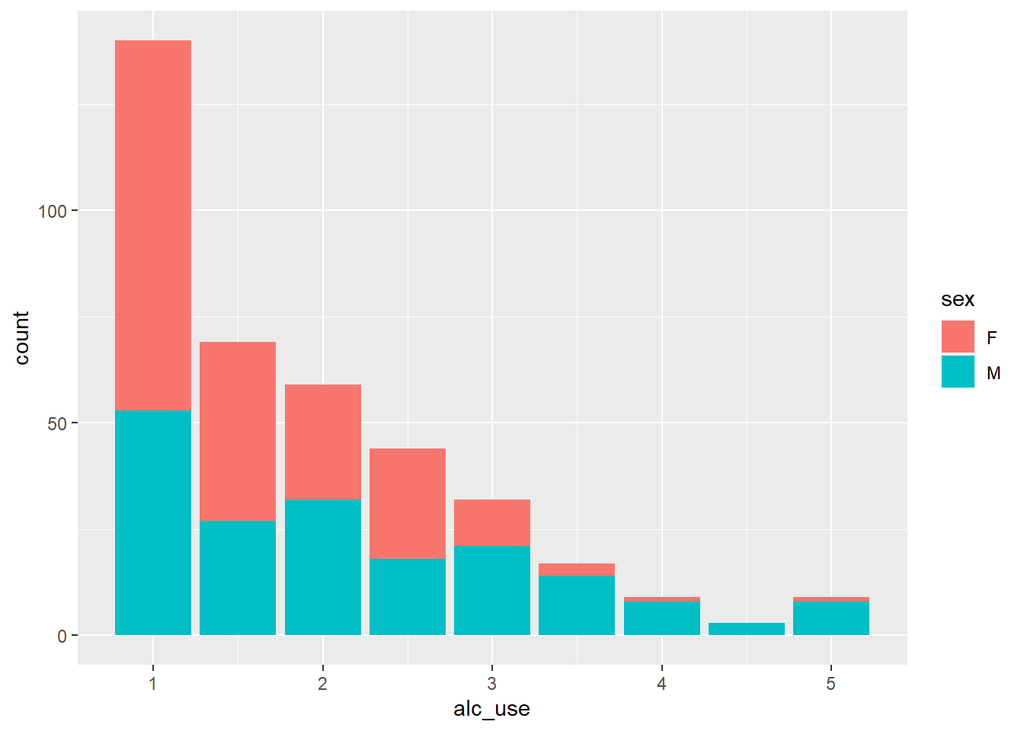

```r
library(dplyr); library(ggplot2)
alc <- mutate(alc, alc_use = (Dalc + Walc) / 2)
alc <- mutate(alc, high_use = alc_use > 2)
g1 <- ggplot(data = alc, aes(x = alc_use,fill=sex))
g1 + geom_bar()
```

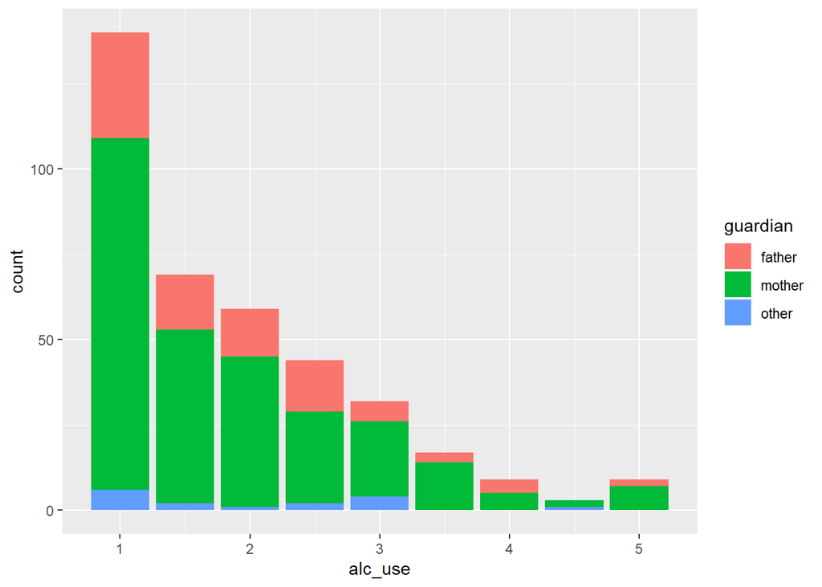

```r
g2 <- ggplot(data = alc, aes(x = alc_use,fill=guardian ))
g2+ geom_bar()
```

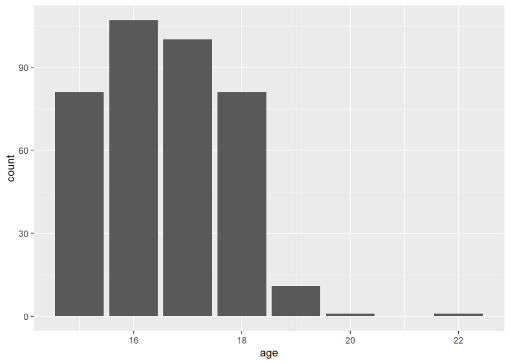

```r
g3 <- ggplot(data = alc, aes(x= age))
g3+ geom_bar()
```

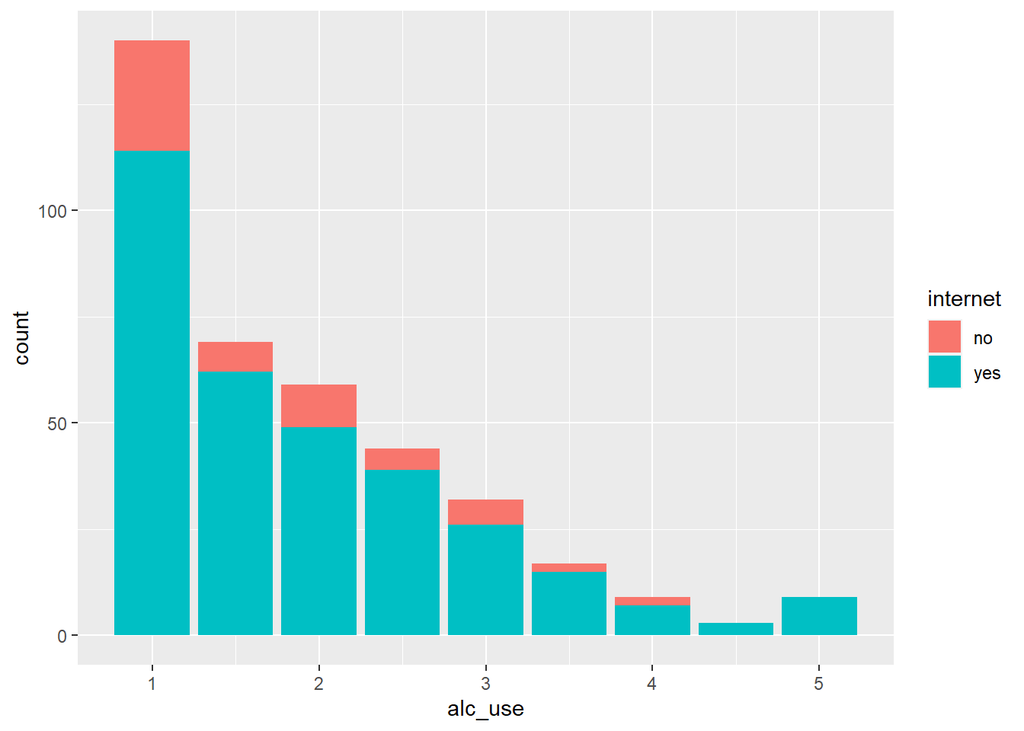

```r
g4 <- ggplot(data = alc, aes(x = alc_use,fill=internet ))
g4+ geom_bar()
```